# Social Network Analysis/Demonstration

Emotional Well-Being and Physical Health, University College London

Milena Tsvetkova

July 13, 2022

## Outline

1. Basic network terminology and network data
2. Ego networks
3. Whole networks

We will work with three R packages: `igraph`, `egor`, and `dplyr`. The package `igraph` provides versatile tools for network data import, manipulation, visualization, and analysis (see more at http://igraph.org/r/). The package `egor` does the same but specifically for ego network data (see more at https://egor.tillt.net/). Finally, the package `dplyr` provides functions and dedicated grammar for data manipulation (see more at https://dplyr.tidyverse.org/).

Run the code below to install the latest version of the packages if you don’t have them already:

```r
#install.packages("igraph")
#install.packages("egor")
#install.packages("dplyr")
```

## Network terminology and data

Social network analysis stems from a number of disciplines - mathematics, sociology, physics, and computer science. As a result, network scientists use multiple terms that may overlap in meaning. For example, one may interchangeably use the terms “node” or “vertex.” Similarly, one may describe connections between vertices as “edges”, “ties”, “links”, or “dyads.”

There are two main types of networks we can analyze: ego networks and whole networks.

**Ego network data** typically come from random sample surveys that contain **name generators**: survey questions that prompt survey participants to think about people they know, how often they interact with them, who they are, and whether they know each other. Because the population we sample from is much larger than any individual’s personal network, we typically assume that the observations (both the survey respondents and the contacts they name) are independent and do not overlap. We can hence apply standard statistical models such as linear and logistic regression and make inferences about the population. One of the largest and most prominent data sources of ego network data is the [General Social Survey (GSS)](https://gssdataexplorer.norc.org).

**Whole network data** can also come from name-generator surveys but these surveys aim to be a census of everyone at a particular organization, school, community, village, or any other well defined and delineated group. Another main source of whole network data are digital records of online communication on social media platforms and online communities. In either case, the aim is to get information about everyone in the group/community and how they are connected with each other. It is clear that in this case we cannot treat observations (whether individuals or links) as independent because my friends may be friends of someone else in the network and my friendships relate to the friendship choices of others. If we want to explain the network or how the network affects individual choices and behavior, we need to employ more sophisticated statistical methods that account for the interdependence of observations. Several such methods have been developed: Exponential Random Graph Models, Stochastic Actor Oriented Models, or network permutation approaches, for example. One important source of whole network data is the [The National Longitudinal Study of Adolescent to Adult Health (Add Health)](https://addhealth.cpc.unc.edu/). These days, however, there are also health and well-being studies that use data and text mining techniques to obtain network data from social media platforms such as Twitter (see Munmun De Choudhury’s work for example).

Here, we will briefly introduce both types of data and some simple ways to visualize and analyze them.

Begin by loading the necessary packages.

```r
library(igraph)
library(egor)
library(dplyr)
```

## Ego Networks

Ego network data look like regular survey data, where each row is a respondent and each column contains the respondent’s answer to a survey question. In addition to typical demographic, health, well-being, and similar variables, the data contain variables for each contact the respondent mentioned in the name generator. For example, a variable such as “age1” will record the age of the first contact the respondent mentioned and “sex3”, the sex/gender of the third contact mentioned. In addition, the data may contain measures of the strength and nature of the respondent’s relationship to that person (e.g., “talkto2”) and how well the mentioned persons know each other (e.g., “close12” can record whether respondent’s contact 1 is a close friend of respondent’s contact 2).

As an example, we will use a subset of the 2004 GSS survey data. The complete data, including variable descriptions and actual survey questions, are available here [here](https://gssdataexplorer.norc.org/home). The name generator the survey used is as follows:

> From time to time, most people discuss important matters with other people. Looking back over the last six months - who are the people with whom you discussed matters important to you? Just tell me their first names or initials.

### Reading ego network data from file

We will begin by reading in and processing the data.

```r
# Read data from csv file
egos <- read.csv("data/gss2004_sample.csv", header=T)

# Parse as numeric types
egos$age <- as.numeric(as.character(egos$age))
egos$mntlhlth <- as.numeric(as.character(egos$mntlhlth))

# Create ego id
egos$egoid <- 1:nrow(egos)

# Create network size variable
egos$netsize = rowSums(!is.na(egos[c('sex1', 'sex2', 'sex3', 'sex4', 'sex5')]))

# Recode tie strength to numeric
for (i in c("talkto1", "talkto2", "talkto3", "talkto4", "talkto5")) {
  egos[[i]] <- recode(egos[[i]],
                      "lt once a month"=1,
                      "once a month"=2,
                      "once a week"=3,
                      "almost daily"=4)
}

# Recode relations between contacts to numeric
for (i in c("close12", "close13", "close14", "close15",
            "close23", "close24", "close25",
           "close34", "close35", "close45")) {
  egos[[i]] <- recode(egos[[i]],
                      "total strangers"=0,
                      "know each other"=1,
                      "especially close"=2)
}

# Recode variable health1, which records responses to question:
# "Would you say that in general your health is Excellent, Very good, Good, Fair, or Poor?""
egos$health1 <- recode(egos$health1,
                       "poor"=1,
                       "fair"=2,
                       "good"=3,
                       "very good"=4,
                       "excellent"=5,
                       "DONT KNOW"=NA_real_)

# Note that variable "mntlhlth" stands for "Days of poor mental health past 30 days"
# The question is: "Now thinking about your mental health, which includes stress,
# depression, and problems with emotions, for how many days during the past
# 30 days was your mental health not good?""
```

### Analyzing ego network data

One thing we can already do with the given data is to use simple statistical models to predict outcomes of interest with the **number of close contacts** the respondent mentioned. The hypothesis is that individuals with larger support networks experience fewer problems with their mental and physical health.

```r
# Predict bad mental health
model1 = lm(mntlhlth ~ age + sex + numgiven, data=egos)
summary(model1)
```

```
##
## Call:
## lm(formula = mntlhlth ~ age + sex + numgiven, data = egos)
##
## Residuals:
##     Min      1Q  Median      3Q     Max
## -5.8857 -3.8303 -2.8109  0.7034 27.4149
##
## Coefficients:
##             Estimate Std. Error t value Pr(>|t|)
## (Intercept)  6.06278    0.83220   7.285 6.96e-13 ***
## age         -0.03045    0.01778  -1.713  0.08714 .
## sexmale     -1.62010    0.45926  -3.528  0.00044 ***
## numgiven     0.10037    0.12882   0.779  0.43608
## ---
## Signif. codes:  0 '***' 0.001 '**' 0.01 '*' 0.05 '.' 0.1 ' ' 1
##
## Residual standard error: 6.919 on 909 degrees of freedom
##   (513 observations deleted due to missingness)
## Multiple R-squared:  0.01774,    Adjusted R-squared:  0.0145
## F-statistic: 5.473 on 3 and 909 DF,  p-value: 0.0009933
```

```r
# Predict good general health
model2 = lm(health1 ~ age + sex + numgiven, data=egos)
summary(model2)
```

```
##
## Call:
## lm(formula = health1 ~ age + sex + numgiven, data = egos)
##
## Residuals:
##      Min       1Q   Median       3Q      Max
## -2.67384 -0.71709  0.09192  0.99417  2.03553
##
## Coefficients:
##              Estimate Std. Error t value Pr(>|t|)
## (Intercept)  4.021472   0.174803  23.006  < 2e-16 ***
## age         -0.012435   0.003259  -3.815 0.000154 ***
## sexmale     -0.139380   0.103666  -1.345 0.179407
## numgiven     0.103814   0.030080   3.451 0.000607 ***
## ---
## Signif. codes:  0 '***' 0.001 '**' 0.01 '*' 0.05 '.' 0.1 ' ' 1
##
## Residual standard error: 1.135 on 487 degrees of freedom
##   (935 observations deleted due to missingness)
## Multiple R-squared:  0.05691,    Adjusted R-squared:  0.0511
## F-statistic: 9.796 on 3 and 487 DF,  p-value: 2.765e-06
```

We find that men report fewer days of bad mental health in the past month but the number of close social contacts does not seem to have an effect.

Regarding general health however, we do find a social effect. Controlling for the fact that health deteriorates with age, we find that respondents who name a higher number of close social contacts report better health.

If we want to conduct a more sophisticated analysis, we can use the specialized library `egor`. This requires some additional data pre-processing.

```r
# Create egor object from data
# Source: https://cran.r-project.org/web/packages/egor/vignettes/qualtrics.html
e1 <- onefile_to_egor(egos = egos,
                      netsize = egos$netsize,
                      ID.vars = list(ego = "egoid"),
                      attr.start.col = "sex1",  # Name of Variable with the first alter attribute
                      attr.end.col = "talkto5",  # Name of variable with last alter attribute
                      max.alters = 5,  # Number of maximum alters that were named by participants
                      aa.first.var = "close12")  # Name of first alter-alter variable
```

```
## Sorting data by egoID: Transforming alters data to long format: Transforming wide dyad data to edgelist: Filtering out empty alter entries using provided network size values:
```

```r
e1
```

```
## # EGO data (active): 1,426 x 7
##   .egoID sex      age numgiven mntlhlth health1 netsize
##   <chr>  <fct>  <dbl>    <int>    <dbl>   <dbl>   <dbl>
## 1 1      female    52        0       NA      NA       0
## 2 2      female    43        0       NA      NA       0
## 3 3      male      52        4        0      NA       4
## 4 4      female    34        4        1       4       4
## 5 5      male      22        0       NA       4       0
## # ALTER data: 2,845 x 4
##   .altID .egoID sex    talkto
##   <chr>  <chr>  <fct>   <dbl>
## 1 1      3      female      1
## 2 2      3      female      4
## 3 3      3      male        3
## # AATIE data: 2,743 x 4
##   .egoID .srcID .tgtID weight
##   <chr>  <chr>  <chr>   <dbl>
## 1 3      1      2           1
## 2 3      1      3           2
## 3 3      2      3           2
```

```r
summary(e1)
```

```
## 1426 Egos/ Ego Networks
## 2845 Alters
## Min. Netsize 1
## Average Netsize 2.6588785046729
## Max. Netsize 5
## Average Density 0.829066328686101
## Alter survey design:
##   Maximum nominations: 5
```

The library allows to visualize the ego networks and more importantly, easily obtain important ego network metrics that we can then enter in models to predict outcomes of interest.

### Advanced ego network metrics

#### Density

This metric estimates the proportion (or strength) of ties among the respondent’s close contacts that are present out of all possible. For example, if I have three friends, there are three possible links between them: 1 and 2, 1 and 3, and 2 and 3. If only the first two exist but friend 2 and 3 do not know each other, then the density is 2/3 = 0.667. Density is undefined when the size of the network is < 2.

```r
ego_density(e1)
```

```
## # A tibble: 1,426 x 2
##    .egoID density
##    <chr>    <dbl>
##  1 1      NaN
##  2 2      NaN
##  3 3        0.833
##  4 4        0.833
##  5 5      NaN
##  6 6        0.9
##  7 7      NaN
##  8 8        0
##  9 9      NaN
## 10 10       0
## # … with 1,416 more rows
```

#### Network composition

This metric estimates the composition of the respondent’s network for a given characteristic.

```r
composition(e1, "sex") %>%
  head()
```

```
## # A tibble: 6 x 4
##   .egoID    .a female   male
##   <chr>  <dbl>  <dbl>  <dbl>
## 1 10        NA  0.5    0.5
## 2 1000      NA  0.6    0.4
## 3 1001      NA  0.667  0.333
## 4 1003      NA NA      1
## 5 1004      NA  1     NA
## 6 1006      NA  0.2    0.8
```

```r
# Notice that .egoID is sorted differently in this case, so you will need to
# manipulate the data before joining with the original dataset
```

We can use metrics like these to conduct more sophisticated analyses of network effects. A plausible hypothesis is that dense networks provide more support and hence, individuals with denser networks will experience fewer mental health problems. Notice, however, that since density is not defined for networks of size 0 or 1, the model is restricted to a much smaller subsample.

```r
# Add density estimates to original data
egos$dens <- ego_density(e1)$density

# Predict bad mental health with network size and density
model1 = lm(mntlhlth ~ age + sex + numgiven + dens, data=egos)
summary(model1)
```

```
##
## Call:
## lm(formula = mntlhlth ~ age + sex + numgiven + dens, data = egos)
##
## Residuals:
##     Min      1Q  Median      3Q     Max
## -7.2295 -4.0996 -2.4282  0.3951 27.1336
##
## Coefficients:
##             Estimate Std. Error t value Pr(>|t|)
## (Intercept)  8.61397    1.59674   5.395 1.04e-07 ***
## age         -0.05335    0.02372  -2.249   0.0249 *
## sexmale     -1.30452    0.62171  -2.098   0.0364 *
## numgiven    -0.08802    0.23928  -0.368   0.7131
## dens        -1.24459    1.06772  -1.166   0.2443
## ---
## Signif. codes:  0 '***' 0.001 '**' 0.01 '*' 0.05 '.' 0.1 ' ' 1
##
## Residual standard error: 7.077 on 519 degrees of freedom
##   (902 observations deleted due to missingness)
## Multiple R-squared:  0.02114,    Adjusted R-squared:  0.0136
## F-statistic: 2.802 on 4 and 519 DF,  p-value: 0.02535
```

The coefficient for density is negative as predicted but the effect is not statistically significant. Thus, in this case, we do not find statistical evidence for the hypothesized effect.

## Whole Networks

Whole network data are most commonly supplied in the form of node and edge lists. An edge list takes the form of a data frame with at least two columns: the first is the “ego” or “source” vertex and the second – the “alter” or “target” vertex. It is also possible to include additional columns that contain information about the specific relationship, e.g., its strength. Edge lists record every connection that exists in the network. This means that if there are **isolates** in the network, i.e. nodes that have no connections, they will not be present in the edge list. The node list contains all nodes, including the isolates, together with node properties such as socio-demographic characteristics, opinions, health and well-being indicators, and many others.

As an example, we will use a synthetic dataset that was generated to approximate a school network. The data contain friendship relations, and the students’ grade, sex, and race. You can read more about the data [here](https://rdrr.io/github/statnet/statnet.data/man/faux.dixon.high.html).

### Reading network data from files

```r
# We first read the csv data into the native R dataframe type
nodes <- read.csv("data/dixon_high_nodes.csv", header=T, as.is=T)
edges <- read.csv("data/dixon_high_edgelist.csv", header=T, as.is=T)

# Next, we create a single igraph object from the two dataframes
# The object represents a directed network
dixon <- graph_from_data_frame(d=edges, vertices=nodes, directed=T)

# Calling the object gives us a summary and attempts to print all edges
# You can also use summary(dixon) or print(dixon) to the same effect
dixon
```

```
## IGRAPH 5a86a12 DN-- 248 1197 --
## + attr: name (v/c), grade (v/n), race (v/c), sex (v/n)
## + edges from 5a86a12 (vertex names):
##  [1] 1 ->97  1 ->100 1 ->122 1 ->128 1 ->155 1 ->189 2 ->46  2 ->49  2 ->52
## [10] 2 ->64  2 ->69  2 ->174 2 ->189 3 ->36  4 ->7   4 ->81  4 ->162 6 ->16
## [19] 6 ->110 6 ->232 7 ->221 7 ->246 8 ->28  8 ->88  8 ->159 8 ->184 8 ->197
## [28] 8 ->231 8 ->243 9 ->46  9 ->126 9 ->171 10->48  10->128 10->134 10->185
## [37] 10->231 11->19  11->21  11->26  11->66  11->78  11->139 11->174 12->36
## [46] 12->49  12->97  12->112 12->127 12->174 12->189 12->206 13->201 15->26
## [55] 15->54  15->56  15->66  15->69  15->113 15->135 15->174 17->4   17->81
## [64] 17->162 17->242 17->248 19->11  19->14  19->21  19->149 19->202 19->228
## + ... omitted several edges
```

We can see that the network is directed and has 248 node and 1197 edges. Using `E()` and `V()` and the `$` operator, we can also access specific attributes associated with the edges and the vertices:

```r
V(dixon)$sex
```

```
##   [1] 2 1 2 2 2 2 1 2 2 1 2 1 1 1 2 2 1 1 1 2 2 2 1 1 1 1 1 1 1 2 1 2 2 2 1 1 1
##  [38] 2 2 2 2 2 1 1 1 1 2 1 1 1 1 1 1 1 1 2 1 2 1 2 2 2 1 1 2 1 2 1 1 1 1 2 2 1
##  [75] 1 1 2 1 1 2 2 1 2 1 1 1 2 2 2 1 2 1 1 2 1 2 1 2 2 1 2 1 2 1 1 2 2 1 2 1 1
## [112] 2 2 2 1 1 2 2 2 1 1 2 1 1 2 2 2 2 2 2 2 2 2 1 2 1 2 2 2 1 2 2 2 1 2 2 2 2
## [149] 2 1 1 1 1 1 2 2 1 1 2 1 2 1 2 2 1 1 2 1 1 2 1 2 2 1 1 2 2 2 2 1 2 2 2 2 1
## [186] 1 1 1 1 1 1 1 1 1 2 2 2 2 2 2 1 1 1 2 2 1 1 2 1 1 2 1 2 2 2 1 2 1 2 1 1 2
## [223] 1 1 1 2 2 1 1 2 1 1 2 1 1 2 1 1 2 2 2 2 2 2 2 1 1 2
```

### Visualizing networks

We can simply call `plot` to visualize the network.

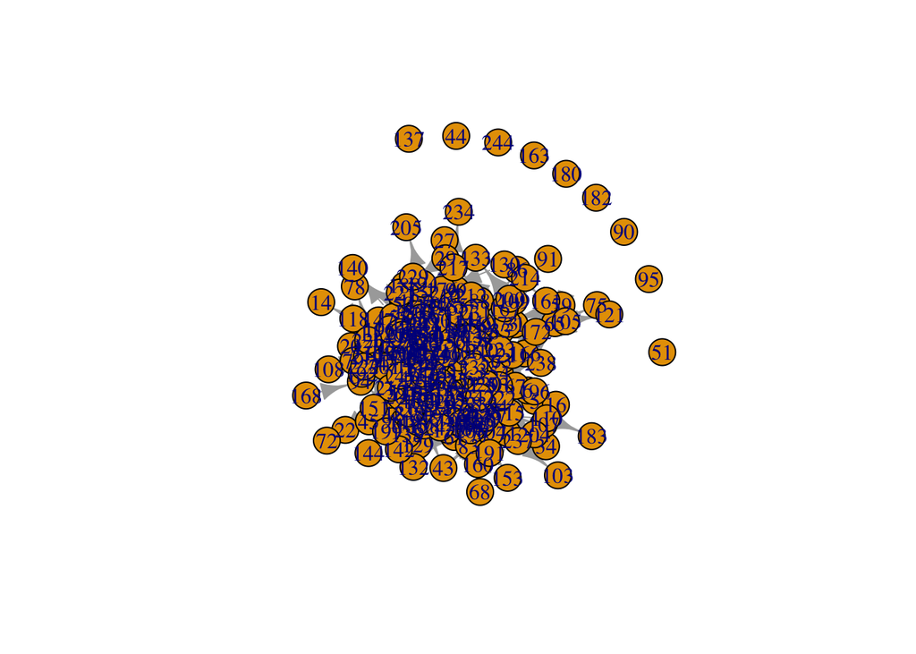

```r
plot(dixon)
```

The patterns are difficult to see in the plot because the nodes overlap and the node labels create a clutter. To improve the visualization, we will remove the vertex labels and specify values for the edge arrow size and the vertex size. There is no silver bullet here, the optimal values will depend on the network size and structure. Beautiful network visualizations usually require much tinkering and trial and error!

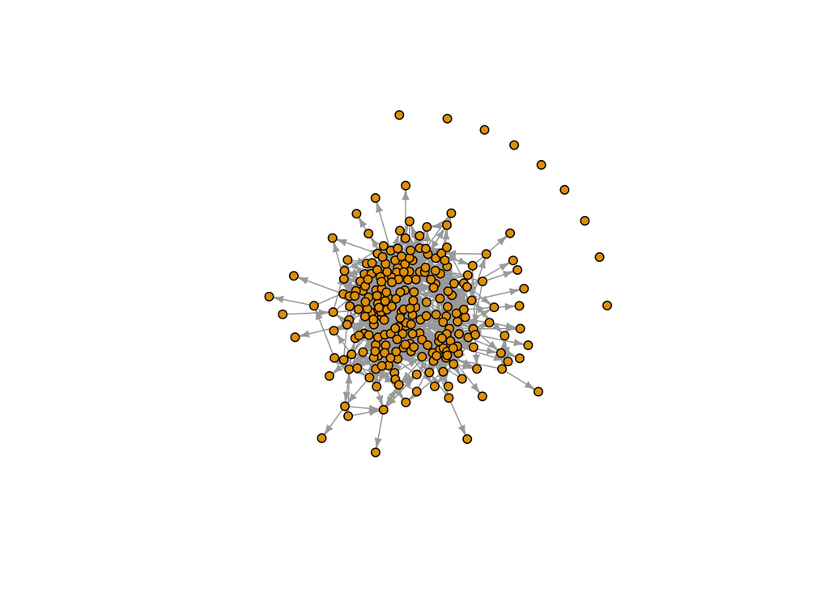

```r
plot(dixon, edge.arrow.size=.4, vertex.size=5, vertex.label=NA)
```

We can now clearly see that the network has a **core-periphery structure**, with some students more popular than others. We also observe nine **isolates** – nodes that have no friendship links to anyone.

We can get further insights about the network when we color the nodes by gender or race.

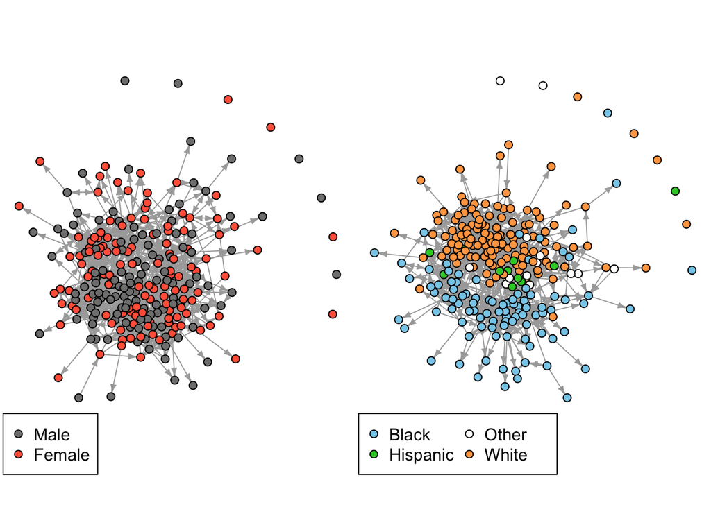

```r
# Create two plots next to each other
par(mfrow=c(1, 2), mar=c(1.5, .1, .1, .1))

# For sex, generate a vector of colors to correspond to the two different values
sex_cols <- c("gray50", "tomato")

# Use the values from the data to index from sex_cols
plot(dixon, edge.arrow.size=.4, vertex.size=5, vertex.label=NA,
     vertex.color=sex_cols[V(dixon)$sex])
# Add a legend to explain the values
legend(x=-1.1, y=-1.1, c("Male", "Female"), pch=21, pt.bg=sex_cols)


# For race, we cannot use the values to index, so instead create a dataframe to map the colors
race_cols <- data.frame(race = c('B', 'H', 'O', 'W'),
              color = c('skyblue', 'limegreen', 'white', 'tan1'), stringsAsFactors = F)
# Use the values in the data to get the correct indeces for the color map
plot(dixon, edge.arrow.size=.4, vertex.size=5, vertex.label=NA,
     vertex.color=race_cols$color[match(V(dixon)$race, race_cols$race)])
# Add a legend
legend(x=-1.1, y=-1.1, c("Black", "Hispanic", "Other", "White"), pch=21, pt.bg=race_cols$color, ncol=2)
```

The plots show **assortativity** by sex and even more so by race, meaning that links are observed more often between students who have the same sex or the same race. This could be due to **homophily**, or the preference for similar others, but also institutional and organizational constraints and biases - e.g., racial segregation in residential neighborhoods.

### Common network metrics

There are multiple important metrics that help us describe and understand the structure of networks.

#### Reciprocity

For a directed network, reciprocity measures the proportion of edges that are reciprocated. Friendship networks usually have high reciprocity, which means that friendship nominations tend to be mutual.

```r
reciprocity(dixon)
```

```
## [1] 0.3659148
```

#### Transitivity

Transitivity measures the proportion of triads with the links A-B and A-C where the link B-C is also present. Transitivity is a measure of clustering, or the idea that “the friend of my friend is my friend too.”

```r
transitivity(dixon)
```

```
## [1] 0.1812741
```

#### Node centrality

There are many different ways to conceptualize and measure the importance of nodes in a network. One metric that presents an intuitive understanding of popularity is **indegree** – we simply count how many times others name the focal node as a friend. We can use the function `degree()` with the parameter `mode="in"` to estimate the indegrees of all nodes in the network.

```r
# Estimate the average indegree in the network
mean(degree(dixon, mode="in"))
```

```
## [1] 4.826613
```

We will now plot the network again but this time the size of nodes will correspond to their popularity.

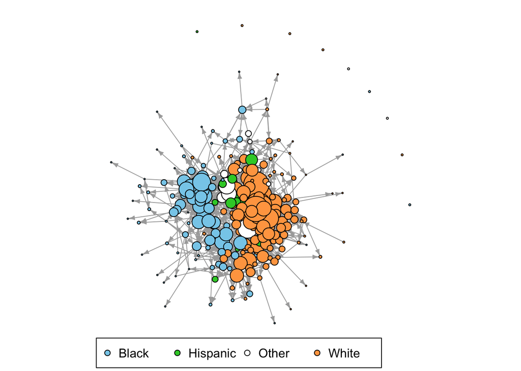

```r
# Set up the margins to make sure the legend is not cut off
par(mar=c(1.5, 0, 0, 0))

# Estimate the indegree to use to size up the nodes
indeg <- degree(dixon, mode="in")

# Notice how we use the indeg vector to specify vertex.size
plot(dixon, edge.arrow.size=.4, vertex.size=indeg, vertex.label=NA,
     vertex.color=race_cols$color[match(V(dixon)$race, race_cols$race)])

legend(x=-1.1, y=-1.1, c("Black", "Hispanic", "Other", "White"), pch=21,
       pt.bg=race_cols$color, horiz=TRUE)
```

We notice that white students tend to be more popular than black students. However, this may be partially driven by the fact that white students tend to name other white students as friends and white students are the largest race group in this school.

#### Assortativity

We can quantify the extent of assortativity in the network with several functions. For categorical variables such as sex and race, we can use `assortativity_nominal()`, for ordinal and continuous variables – `assortativity()`, and for degrees specifically – `assortativity_degree()`. Intuitively, assortativity can vary from 1 to -1, where 1 means that links occur only between identical others and -1 means that similar individuals avoid each other and links occur only between dissimilar others. Due to homophily, friendship networks tend to have positive assortativity but due to heterosexuality being dominant, sexual preference networks tend to exhibit negative assortativity.

```r
print(assortativity_nominal(dixon, V(dixon)$sex, directed=F))
```

```
## [1] 0.1357449
```

```r
# Notice we force race to be treated as factor variable as otherwise we get an error
print(assortativity_nominal(dixon, factor(V(dixon)$race), directed=F))
```

```
## [1] 0.5760707
```

These measures allow us to quantify what we already observed in one of the plots above, namely, that assortativity by race is much stronger than assortativity by gender.